# Lab 3 Notebook

DATA: country

Often we need to change the level of measurement of a variable. It is common, for example, to collapse interval-ratio level variables into nominal or ordinal variables. It is not possible to transform nominal or ordinal variables into interval-ratio variables. We can create a new nominal/ordinal version of an interval-ratio variable by recoding it. Recoding a variable should follow this important rule: Variables should be exhaustive and mutually exclusive (meaning: every observation must fit into a category, but only one category).

In this lab we will learn some basic variable creation and recoding techniques. As usual the lab gets into some more advanced applications (including how to create R functions which can automate this process)

Before you recode a variable, you need to decide the coding scheme. To decide the coding scheme, you need to understand the variable’s distribution:

Recode the variable physicians into an ordinal variable

First, look at the distribution of physicians:

`r`r summary(country$physicians)

```
   Min. 1st Qu.  Median    Mean 3rd Qu.    Max.    NA's
   2.00   25.25  107.50  170.90  250.00 4735.00       3
```

`r`r hist(country$physicians)

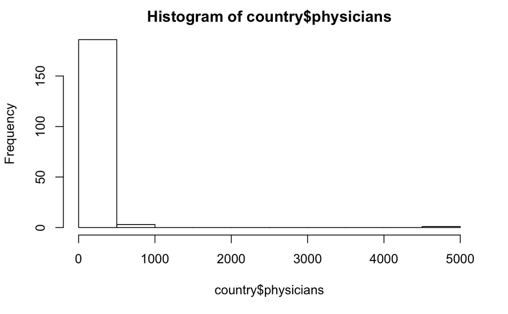

```r
quantile(country$physicians, seq(0, 1, 0.1), na.rm=TRUE)
```

```
    0%    10%    20%    30%    40%    50%    60%    70%    80%    90%   100%
   2.0    7.8   16.0   34.0   57.6  107.5  135.8  215.5  301.0  356.3 4735.0
```

Second, use subset assignment statements to assign an ordinal coding scheme for a new variable that we’ll name physiciansCat

```r
country$physiciansCat[country$physicians <= 25] <- 1
```

```
Unknown or uninitialised column: 'physiciansCat'.
```

```r
country$physiciansCat[country$physicians > 25 & country$physicians <= 100] <- 2
country$physiciansCat[country$physicians > 100 & country$physicians <= 250] <- 3
country$physiciansCat[country$physicians > 250] <- 4
```

Third, convert the new variable to a “factor” (to indicate that it’s nominal or ordinal) and assign value labels:

`r`r country$physiciansCat <- factor(country$physiciansCat, labels=c(‘0-25 physicians per 100k’, ‘26-100 physicians per 100k’, ‘101-250 physicians per 100k’, ‘>250 physicians per 100k’))

If you need to start over, Null out the new variable. DONT RUN THIS UNLESS YOU HAVE A PROBLEM!!

`r`r country$physiciansCat <- NULL

Fourth, Check your work: 1. look at the distribution of the new variable and compare it to the distribution of the old variable 2. use the tapply function to summarize the old variable across categories of the new ordinal variable

```r
tapply(country$physicians, country$physiciansCat, summary)
```

```
$`0-25 physicians per 100k`
   Min. 1st Qu.  Median    Mean 3rd Qu.    Max.
   2.00    4.75   10.50   10.15   15.00   25.00

$`26-100 physicians per 100k`
   Min. 1st Qu.  Median    Mean 3rd Qu.    Max.
  26.00   36.25   50.00   52.10   60.00   92.00

$`101-250 physicians per 100k`
   Min. 1st Qu.  Median    Mean 3rd Qu.    Max.
  101.0   120.5   140.0   159.2   202.2   247.0

$`>250 physicians per 100k`
   Min. 1st Qu.  Median    Mean 3rd Qu.    Max.
  251.0   314.5   340.0   448.3   400.0  4735.0
```

IN-CLASS EXERCISE

Recode mort2004 into an ordinal variable:

1. Look at its distribution to decide on a coding scheme that creates THREE categories
2. Create a new variable that implements your coding scheme
3. Convert it to a factor and label the values
4. Create the description variable
5. Check your work
6. Create a crosstab of physicians and infant mortality
7. Look at its distribution to decide on a coding scheme that creates THREE categories
1. First, look at the distribution of mort2004

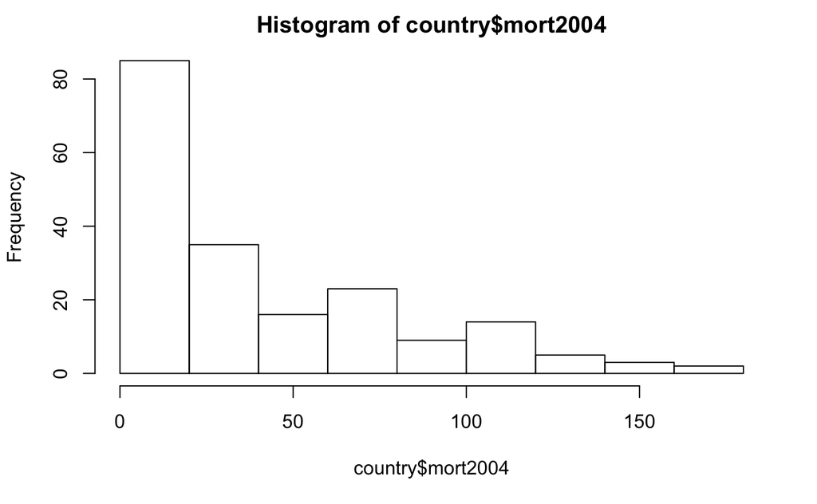

```r
hist(country$mort2004)
quantile(country$mort2004, seq(0, 1, 0.05), na.rm=TRUE)
```

```
    0%     5%    10%    15%    20%    25%    30%    35%    40%    45%    50%    55%
  2.00   4.00   5.00   5.00   7.00  10.00  13.00  16.00  18.00  21.00  24.50  29.05
   60%    65%    70%    75%    80%    85%    90%    95%   100%
 33.60  48.15  58.70  68.00  78.00  87.70 102.00 119.35 165.00
```

2. Next, use subset assignment statements to assign an ordinal coding scheme for a new variable that we’ll name mort2004Cat

```r
country$mort2004Cat[country$mort2004 <= 15] <- 1
```

```
Unknown or uninitialised column: 'mort2004Cat'.
```

```r
country$mort2004Cat[country$mort2004 > 15 & country$mort2004 <= 50] <- 2
country$mort2004Cat[country$mort2004 > 50] <- 3
```

2 &3&4. Convert the new variable to a “factor” (to indicate that it’s nominal or ordinal) and assign value labels

`r`r country$mort2004Cat <- factor(country$mort2004Cat, labels=c(‘Low: 0-15 infant deaths per 1k’, ‘Medium: 16-50 infant deaths per 1k’, ‘High: >50 infant deaths per 1k’))

5. Check your work:
6. look at the distribution of the new variable and compare it to the distribution of the old variable
7. use the tapply funtion to summarize the old variable across categories of the new ordinal variable

```r
tapply(country$mort2004, country$mort2004Cat, summary)
```

```
$`Low: 0-15 infant deaths per 1k`
   Min. 1st Qu.  Median    Mean 3rd Qu.    Max.
  2.000   4.000   6.000   7.182  10.000  15.000

$`Medium: 16-50 infant deaths per 1k`
   Min. 1st Qu.  Median    Mean 3rd Qu.    Max.
  16.00   18.00   24.50   26.28   32.00   49.00

$`High: >50 infant deaths per 1k`
   Min. 1st Qu.  Median    Mean 3rd Qu.    Max.
  52.00   67.25   80.50   90.35  109.50  165.00
```

6. Create a crosstab of physicians and infant mortality

```
                             Infant Mortality Rate
Physicians                    Low: 0-15 infant deaths per 1k
  0-25 physicians per 100k                                 1
  26-100 physicians per 100k                               3
  101-250 physicians per 100k                             26
  >250 physicians per 100k                                35
                             Infant Mortality Rate
Physicians                    Medium: 16-50 infant deaths per 1k
  0-25 physicians per 100k                                     3
  26-100 physicians per 100k                                  24
  101-250 physicians per 100k                                 24
  >250 physicians per 100k                                     8
                             Infant Mortality Rate
Physicians                    High: >50 infant deaths per 1k
  0-25 physicians per 100k                                44
  26-100 physicians per 100k                              15
  101-250 physicians per 100k                              2
  >250 physicians per 100k                                 5
```

```r
prop.table(table(country$physiciansCat, country$mort2004Cat, dnn = c("Physicians", "Infant Mortality Rate")), 2) # column percentage
```

```
                             Infant Mortality Rate
Physicians                    Low: 0-15 infant deaths per 1k
  0-25 physicians per 100k                        0.01538462
  26-100 physicians per 100k                      0.04615385
  101-250 physicians per 100k                     0.40000000
  >250 physicians per 100k                        0.53846154
                             Infant Mortality Rate
Physicians                    Medium: 16-50 infant deaths per 1k
  0-25 physicians per 100k                            0.05084746
  26-100 physicians per 100k                          0.40677966
  101-250 physicians per 100k                         0.40677966
  >250 physicians per 100k                            0.13559322
                             Infant Mortality Rate
Physicians                    High: >50 infant deaths per 1k
  0-25 physicians per 100k                        0.66666667
  26-100 physicians per 100k                      0.22727273
  101-250 physicians per 100k                     0.03030303
  >250 physicians per 100k                        0.07575758
```

Assignment 3 Create a New R Notebook and save it as both html format and PDF format.

Data frame for this assignment: lowbwt 1. List the level of measurement for each of the following variables:

1. LOW
2. LWT (Weight in Pounds at the Last Menstrual Period)
2. Why is it NOT appropriate to create a crosstab using the two variables in the previous question?
3. Recode the variable LWT into a new ordinal variable.
4. Show a frequency table of the new ordinal LWT variable (that you created in #3) and explain your coding scheme.
5. Show a crosstab of Low Birth Weight (LOW) BY Weight in Pounds at the Last Menstrual Period, making sure to use variables at the appropriate levels of measurement.
6. Does there appear to be a relationship between Low Birth Weight and Mother’s weight in pounds at the last menstrual period? Explain.

Submit to Canvas: your answers to these questions AND the R code you used to get the answers.

# Advanced material

Lets create a dummy variable based on a high level of gdp. As a reminder dummy variables are used very heavily in quantitative analysis. Better called “indicator variables” they use a binary coding scheme in which “1” indicates the presence of a characteristic and “0” the absense. First, lets look at the GDP variable to get a good definition of “high”

`r`r summary(country$gdp)

```
   Min. 1st Qu.  Median    Mean 3rd Qu.    Max.    NA's
   90.0   632.8  2342.0  7993.0  7876.0 70300.0      13
```

`r`r hist(country$gdp)

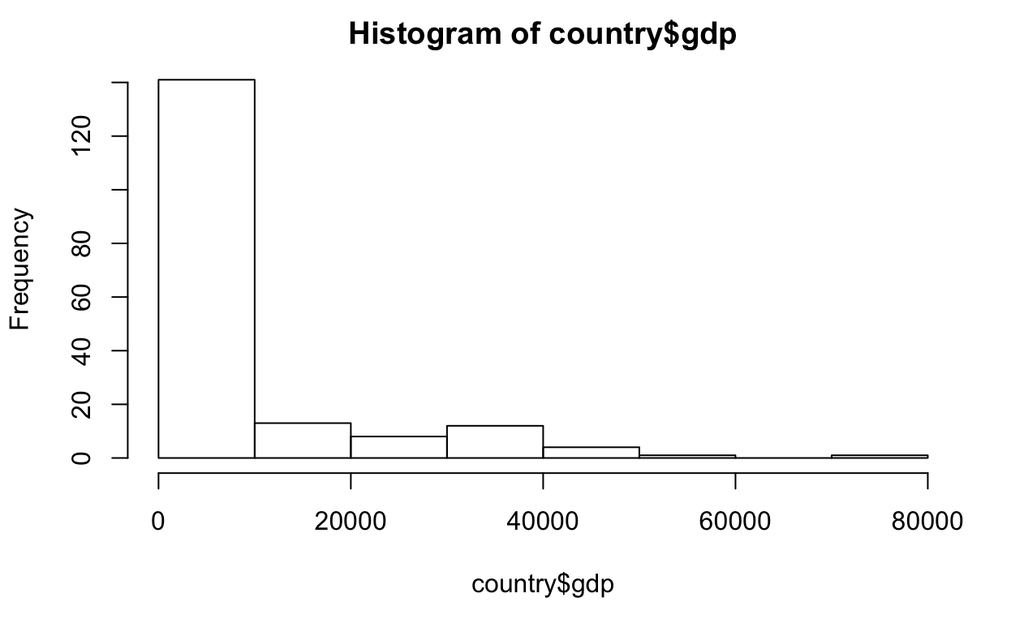

The third quartile value is 7876 so lets go above that and call that “high”. Here I am going to use “if/else” logic which is common in classical programming. Note how simple the code is.

```r
country$gdphigh <- ifelse(country$gdp>7876,1,0)
tapply(country$gdp, country$gdphigh, summary)
```

```
$`0`
   Min. 1st Qu.  Median    Mean 3rd Qu.    Max.
     90     476    1184    2002    2894    7724

$`1`
   Min. 1st Qu.  Median    Mean 3rd Qu.    Max.
   8331   14140   24360   25960   35560   70300
```

```r
dummygen2(country,"gdphigh2","gdp",7876)->country
tapply(country$gdp, country$gdphigh2, summary)
```

```
$`0`
   Min. 1st Qu.  Median    Mean 3rd Qu.    Max.
     90     476    1184    2002    2894    7724

$`1`
   Min. 1st Qu.  Median    Mean 3rd Qu.    Max.
   8331   14140   24360   25960   35560   70300
```

`r`r summary(country$lifespan.range)

```
  [0,40]  (40,50]  (50,60]  (60,70] (70,Inf]     NA's
       9       22       24       57       67       14
```

`r`r table(country$lifespan.range)

```
  [0,40]  (40,50]  (50,60]  (60,70] (70,Inf]
       9       22       24       57       67
```

Here is a more general dummy variable functoin. This one replaces “na” with zero. Make sure that is what you want! There are no instances where this particular code would make sense with this dataset as there are no categorical source variables but you can use this with survey data which has a long of such variables. I don’t actually apply this function here.

Missing values present many issues in data analysis. We’ll be dealing with this in future labs. Here is how you can visualize missings

```
not enough vertical space to display frequencies (too many combinations)

 Variables sorted by number of missings:
       Variable       Count
        cde2003 0.559585492
     inequality 0.347150259
         educ04 0.341968912
      milit2004 0.310880829
         debt04 0.310880829
       tele2004 0.264248705
       cell2003 0.176165803
        hdirank 0.082901554
         hdicat 0.082901554
          lifef 0.072538860
          lifem 0.072538860
 lifespan.range 0.072538860
            gdp 0.067357513
        gdphigh 0.067357513
       gdphigh2 0.067357513
     internet03 0.062176166
        pop2004 0.036269430
     physicians 0.015544041
  physiciansCat 0.015544041
       mort2004 0.005181347
    mort2004Cat 0.005181347
           case 0.000000000
        country 0.000000000
      urban2004 0.000000000
```

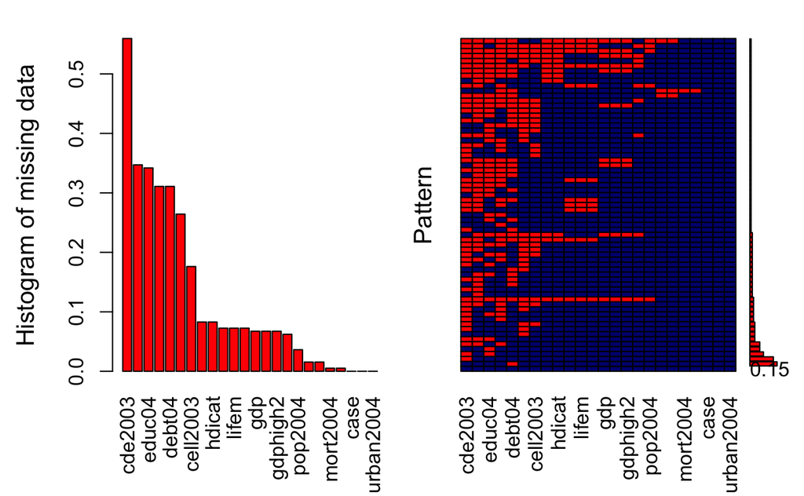

```
 Variables sorted by number of missings:
       Variable      Count
        hdirank 0.08290155
         hdicat 0.08290155
       gdphigh2 0.06735751
           case 0.00000000
        country 0.00000000
        pop2004 0.00000000
      urban2004 0.00000000
     physicians 0.00000000
       mort2004 0.00000000
       tele2004 0.00000000
       cell2003 0.00000000
     internet03 0.00000000
            gdp 0.00000000
     inequality 0.00000000
         educ04 0.00000000
      milit2004 0.00000000
         debt04 0.00000000
        cde2003 0.00000000
          lifef 0.00000000
          lifem 0.00000000
  physiciansCat 0.00000000
    mort2004Cat 0.00000000
        gdphigh 0.00000000
 lifespan.range 0.00000000
```

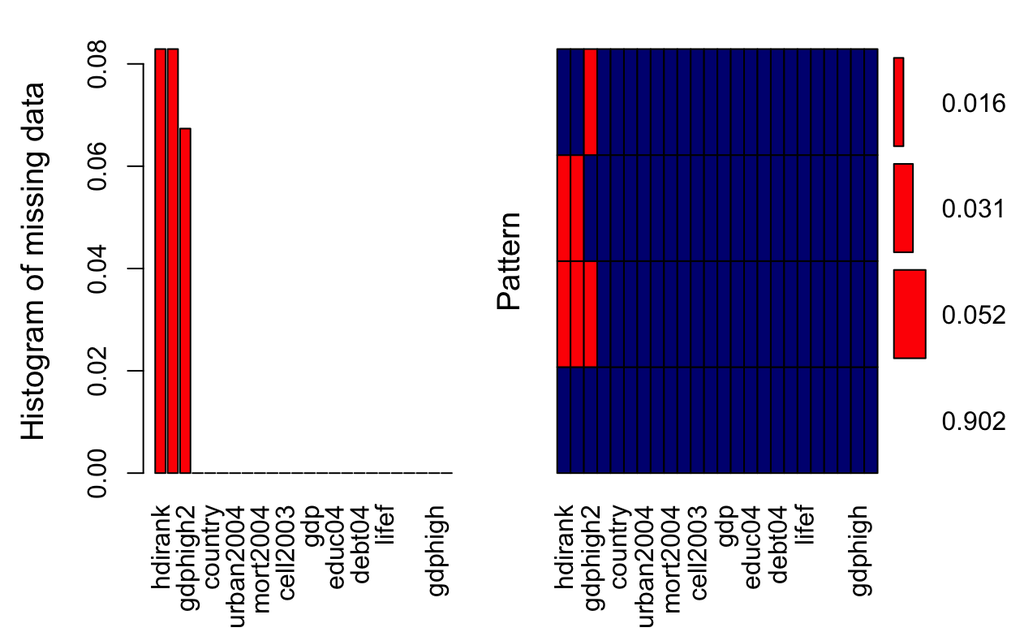

[output not shown]